```python
# Python imports and setup not specific to the subject.
import numpy as np
np.core.arrayprint._line_width = 100
from IPython.core.interactiveshell import InteractiveShell
InteractiveShell.ast_node_interactivity = "all"
from matplotlib import pyplot as plt
from matplotlib.patches import Wedge
plt.rcParams['figure.figsize'] = np.array([6., 4.]) * 2.5
```

# Study different interpolation methods

Given a set of points $x_{interpolation} = \{x_0, x_1, \dots, x_n\}$, a function $f: [a,b] \rightarrow \mathbb{R}$ with $[a,b] \subset \mathbb{R}$ to interpolate in $x_{interpolation}$ (so we now the exact values $y_{interpolation}$), create interpolating polynomials using different methods.

```python
# a, b = 0, 1
a, b = -5, 5
number_of_points = 15
poly_order = number_of_points - 1
verification_step = 1024

# f = lambda x: 3 * np.tan(x) + 1
# Runge test function, to demonstrate that points in equi-spaced points produce a bad interpolation
f = lambda x: 1. / (1 + x**2)

x = np.linspace(a, b, number_of_points)
y = f(x)

tabulation_vector = np.linspace(a, b, verification_step)
```

```python
def plot_interpolation(polynomial=None, tabulated_values=None):
    fig = plt.figure()
    ax = fig.add_subplot(111)
    ax.spines['left'].set_position('zero')
    ax.spines['right'].set_color('none')
    ax.spines['bottom'].set_position('zero')
    ax.spines['top'].set_color('none')

    # remove the ticks from the top and right edges
    ax.xaxis.set_ticks_position('bottom')
    ax.yaxis.set_ticks_position('left')

    # Plot the interpolating points.
    for _x, _y in zip(x, y):
        _ = ax.plot([_x] * 2, [0, _y], "--", color="gray")
    ax.plot(x, np.zeros(x.shape), "bo", label="interpolating points")
    ax.plot(x, y, "ro", label="interpolating values")

    # Plot the function we want to interpolate.
    ax.plot(tabulation_vector, f(tabulation_vector))

    # If given, plot the polynomial in the points of test.
    if polynomial:
        ax.plot(tabulation_vector, polynomial(tabulation_vector), "m-", label="interpolating polynomial")

    if tabulated_values is not None:
        ax.plot(tabulation_vector, tabulated_values, "m-", label="interpolating polynomial")

    ax.legend()
    ax.grid()
    plt.show()
```

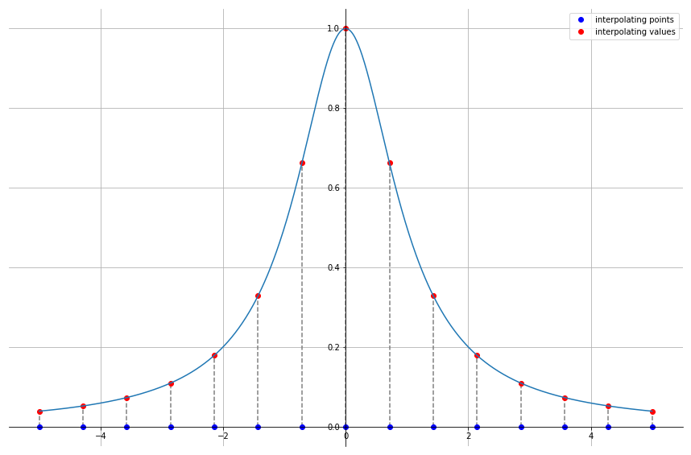

```python
plot_interpolation()
```

## "Canonical" polynomial interpolation

With the canonical polynomial interpolation we want to find the coefficients $a = (a_0, a_1, \dots, a_n)^T$ to apply to the so called Vandermonde matrix $V$, made of the canonical polynomial basis $p = (1, x, x^2, \dots, x^n)$ applied on each of the interpolation points, to interpolate the values $y_{interpolation} = \{y_0, y_1, \dots, y_n\} = \{f(x_0), f(x_1), \dots, f(x_n)\}$ .

The matrix $V$ is: $$V=\begin{bmatrix} 1 & x_0 & x_0^2 & \dots & x_0^n\\ 1 & x_1 & x_1^2 & \dots & x_1^n\\ \vdots & \vdots & \vdots & \ddots &\vdots \\ 1 & x_n & x_n^2 & \dots & x_n^n \end{bmatrix}$$

The linear system to solve is: $V a = y$ .

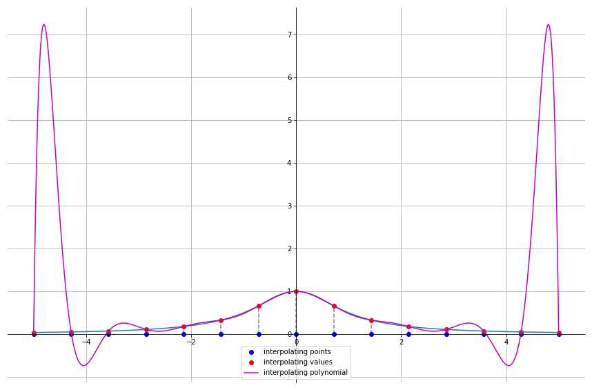

```python
def canonical_interpolation(x, y):
    V = np.vander(x, increasing=True)

    a = np.linalg.solve(V, y)[::-1]
    return np.poly1d(a)

p = canonical_interpolation(x, y)

plot_interpolation(polynomial=p)
```

## Lagrange polynomial interpolation

There's a problem when using the canonical polynomial interpolation: if we increase the number of points to interpolate, the error, which is the "distance" between the polynomial that interpolates and the real function beneath, increases as the power of $n$.

Technically, $V$ is said to be ill-conditioned and (also with a small $n$) $\implies a \neq a^*$ (where $a^*$ stands for the optimal coefficients vector, that produces no errors when the approximation and the real function are compared); to measure how much a linear system in the form $A\, x = b$ is ill-conditioned, the condition number $K(A) = ||A|| \; ||A^{-1}||$ is used.

Instead of using canonical polynomials as the basis of our approximation function, we can construct different polynomials which behave better with an increasing number of points. The specific interpolation representation we're going to use is the Lagrange polynomial interpolation. A basis for the polynomial space can be calculated with:

$$ l_i(x) := \prod\limits_{j=0, j \neq i}\limits^{n} \frac{x - x_j}{x_i - x_j} \quad \text{ with } i = 0, \dots, n $$

We need to construct the matrix $L$, the basis of the polynomial space $\Pi^{\;\!n}$, by applying the formula above on the tabulation vector, the space $[a, b]$ we are studying.

```python
def generate_lagrange_basis(x, number_of_points, tabulation_vector):
    L = np.empty((number_of_points, tabulation_vector.shape[0]))
    for i, x_i in enumerate(x):
        L[i] = np.product([(tabulation_vector - x_j)/(x_i - x_j) for j, x_j in enumerate(x) if i != j], axis=0)
    return L
```

We want to obtain a polynomial $P_n(x)$ such that: $$ P_n(x) = \sum\limits_{i=0}\limits^{n} b_i l_i (x) $$

And we want that the value of the polynomial in the interpolating points matches the value $y_j$ of the function $f$ in the point $x_j$: $$P_n(x_j) = \sum_{i=0}^{n} b_i l_i (x_j) = b_j = y_j $$ since $ l_i (x_j)$ is the Kronecker delta $\delta_{ij}$.

Now the polynomial that approximates $f$ can be constructed by multiplying the Lagrange basis with the value of the function in the interpolating points.

```python
def compute_values_on_lagrange_polynomials(x_points, number_of_points, tabulation_vector, y_values):
    L = generate_lagrange_basis(x_points, number_of_points, tabulation_vector)
    return L.T.dot(y_values)
```

[figure not shown]

```python
values_at_interpolating_points = compute_values_on_lagrange_polynomials(x, number_of_points, tabulation_vector, y)

plot_interpolation(tabulated_values=values_at_interpolating_points)
```

## Newton representation

Let $f[x_0] = f(x_0)$ and $$f[x_0, x] = \frac{f(x) - f(x_0)}{x - x_0} = \frac{f[x] - f[x_0]}{x - x_0}$$

$$f[x_0, \dots, x_n, x] = \frac{\overbrace{f[x_1, \dots, x_n, x]}^\text{last n+1} - \overbrace{f[x_0, \dots, x_n]}^\text{first n+1}}{x - x_0}$$

For $k + 1$ data points we construct the Newton basis as

$$ n_j(x) := \prod_{i=0}^{j-1} (x - x_i) \qquad j=0,\ldots,k $$

Using these polynomials as a basis for $\Pi_k$ we have to solve

$$\begin{bmatrix} 1 & & \ldots & & 0 \\ 1 & x_1-x_0 & & & \\ 1 & x_2-x_0 & (x_2-x_0)(x_2-x_1) & & \vdots \\ \vdots & \vdots & & \ddots & \\ 1 & x_k-x_0 & \ldots & \ldots & \prod_{j=0}^{k-1}(x_k - x_j) \end{bmatrix} \begin{bmatrix} a_0 \\ \\ \vdots \\ \\ a_{k} \end{bmatrix} = \begin{bmatrix} y_0 \\ \\ \vdots \\ \\ y_{k} \end{bmatrix}$$

to solve the polynomial interpolation problem.

```python
def create_newton_matrix(x, number_of_points):
    N_mat = np.zeros((number_of_points, number_of_points))
    N_mat[:, 0] = 1.

    for x_i_idx, x_i in enumerate(x):
        for x_j_idx in range(1, x_i_idx+1):
            x_j_1 = x[x_j_idx-1]
            N_mat[x_i_idx, x_j_idx] = (x_i - x_j_1) * N_mat[x_i_idx, x_j_idx-1]

    return N_mat

create_newton_matrix(x, number_of_points)
```

[output not shown]

```python
a = np.linalg.solve(N_mat, y)[::-1]

p = np.poly1d(a)

plot_interpolation(polynomial=p)
```

[output not shown]

# Interpolating using Chebyshev's nodes

Chebyshev's nodes are a particular set of nodes that are more dense at the extremes of the interpolation interval, thus are able to store "more information" from the original function to interpolate.

To scale the nodes to a generic interval $(a, b)$, we can use:

$$x_{[a,b]} = \frac{1}{2} ( a + b ) + \frac{1}{2} ( b − a ) \; x_{[-1, 1]} $$

```python
def compute_cheby(n_pts, interval=(-1, 1)):
    a, b = interval
    _n_spaces = n_pts+1
    angles = np.pi/_n_spaces * np.arange(1, _n_spaces)
    x_orig, y_orig = np.cos(angles), np.sin(angles)

    # Scale the values to the (a, b) interval.
    scaler = lambda arr: .5 * (a + b) + (.5 * (b - a)) * arr

    return scaler(x_orig), scaler(y_orig)
```

[figure not shown]

```python
_n_pts = 12

_x_cheby, _y_cheby = compute_cheby(_n_pts, interval=(a, b))

plt.rcParams['figure.figsize'] = np.array([4., 4.]) * 1.8
fig = plt.figure()
an = np.linspace(0, 1 * np.pi, 100)
_height = .5 * (b - a)
_margin = (b - a) * .1

ax = fig.add_subplot(111)
ax.set_aspect('equal', 'box')
_ = ax.plot(.5 * (b - a) * np.cos(an), .5 * (b - a) * np.sin(an))

_ = ax.plot(_x_cheby, _y_cheby, "bo")

for _x, _y in zip(_x_cheby, _y_cheby):
    _ = ax.plot([_x] * 2, [0, _y], "--", color="gray")
_ = ax.plot(_x_cheby, np.zeros_like(_x_cheby), "ro", label="chebyshev nodes")

ax.spines['left'].set_position('zero')
ax.spines['right'].set_color('none')
ax.spines['bottom'].set_position('zero')
ax.spines['top'].set_color('none')

# remove the ticks from the top and right edges
ax.xaxis.set_ticks_position('bottom')
ax.yaxis.set_ticks_position('left')
_ = ax.set_xlim(np.array([a - _margin, b + _margin]))
_ = ax.set_ylim(np.array([-_margin, _height + _margin]))
_ = ax.legend()
ax.grid()
fig.tight_layout()

plt.rcParams['figure.figsize'] = np.array([6., 4.]) * 2.5
```

If we use Chebyshev's nodes on the Runge function, we obtain a better approximating interpolation than using equispaced points.

```python
number_of_points = 50
cheby_points, _ = compute_cheby(number_of_points, interval=(a, b))
y_in_cheby = f(cheby_points)
```

### Canonical interpolation

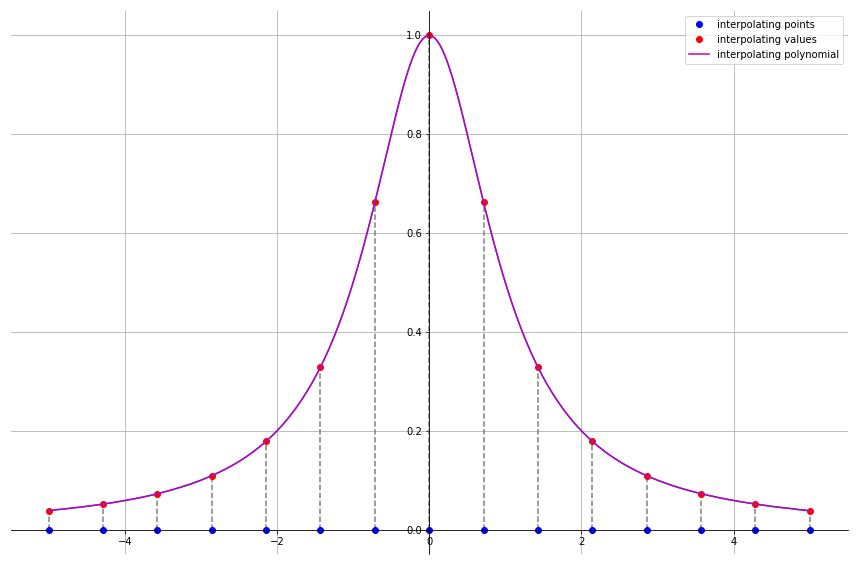

```python
p = canonical_interpolation(cheby_points, y_in_cheby)

plot_interpolation(polynomial=p)
```

### Lagrange interpolation

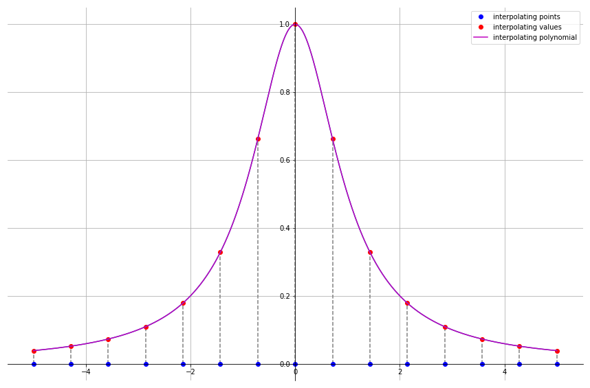

```python
values_at_interpolating_points = compute_values_on_lagrange_polynomials(cheby_points, number_of_points, tabulation_vector, y_in_cheby)

plot_interpolation(tabulated_values=values_at_interpolating_points)
```